# Project_week4

### Задание 4 неделя

1. Составьте из данных о поездках прямоугольную таблицу так, чтобы по строкам было время, а по столбцам идентификатор ячейки (возьмите только те, которые были отобраны на второй неделе). Не используйте данные за последние имеющиеся месяцы — май и июнь 2016!
2. Перед проведением кластеризации стандартизуйте столбцы (вычтите выборочное среднее и поделите на выборочную дисперсию). Это необходимо, поскольку при выборе модели ARIMA имеет значение только форма ряда, но не его средний уровень и размах колебаний.
3. Кластеризуйте географические зоны по значениям стандартизованных рядов. Подберите число кластеров так, чтобы оно было не слишком большим, но ряды внутри кластеров имели похожую форму. Постройте графики стандартизованных рядов каждого кластера, чтобы в этом убедиться.
4. В каждом кластере выберите наиболее типичный ряд (например, это может быть ряд, соответствующий центру кластера).
5. Для выбранных географических зон подберите на исходных рядах оптимальную структуру моделей — набор регрессионных признаков и значения гиперпараметров p,d,q,P,D,Qp,d,q,P,D,Q — так, как это делалось на прошлой неделе. Не используйте данные за последний имеющийся месяц — май и июнь 2016!
6. Для каждой из RR географических зон настройте на данных до апреля 2016 включительно модель ARIMA с гиперпараметрами, соответствующими кластеру этой зоны. Для каждого конца истории от 2016.04.30 23:00 до 2016.05.31 17:00 постройте прогноз на 6 часов вперёд и посчитайте в ноутбуке ошибку прогноза по следующему функционалу:
7. Для каждой из RR географических зон настройте на данных до мая 2016 включительно модель ARIMA с гиперпараметрами, соответствующими кластеру этой зоны. Для каждого конца истории от 2016.05.31 23:00 до 2016.06.30 17:00 постройте прогноз на 6 часов вперёд и запишите все прогнозы в файл в формате id,y, где столбец id состоит из склеенных через подчёркивание идентификатора географической зоны, даты конца истории, часа конца истории и номера отсчёта, на который делается предсказание (1-6); столбец y — ваш прогноз.
8. Загрузите полученный файл на kaggle: https://inclass.kaggle.com/c/yellowtaxi. Добавьте в ноутбук ссылку на сабмишн.
9. Загрузите ноутбук в форму.

### Импорт библиотек

```python
pip install geojson
```

```python
import pandas as pd
import numpy as np
from scipy.stats import binned_statistic_2d
from google.colab import drive
import matplotlib.pyplot as plt
from sklearn.preprocessing import StandardScaler
import datetime
from sklearn.cluster import KMeans
from sklearn import linear_model, model_selection, metrics
import statsmodels.api as sm
from sklearn.linear_model import ElasticNet
from sklearn.decomposition import PCA, TruncatedSVD
from sklearn.manifold import MDS, TSNE
from sklearn.metrics import pairwise_distances
from sklearn.random_projection import SparseRandomProjection
from itertools import product
import warnings
from joblib import dump, load
import warnings
warnings.filterwarnings("ignore")
import folium
import geojson
from pandas.tseries.holiday import USFederalHolidayCalendar
import csv

from scipy.spatial import distance


drive.mount('/final_project/')

%cd "/final_project/MyDrive/final_project"
%ls
```

### Функции

```python
def preproccessing_and_aggregation_data(file, REGIONS, NY_LOCATION):


  data = pd.read_csv(file, parse_dates=['tpep_pickup_datetime', 'tpep_dropoff_datetime'])

  # удаляем поездки с нулевой длительностью
  data = data[data['tpep_dropoff_datetime'] != data['tpep_pickup_datetime']]

  # удаляем поездки с нулевым количеством пассажиров
  data = data[data.passenger_count != 0]

  # удаляем поездки с нулевым расстояние поездки
  data = data[data.trip_distance != 0]

  # удаляем поездки с координатами не в Нью-Йорке
  data = data[((data.pickup_longitude > NY_LOCATION[0]) & (data.pickup_longitude < NY_LOCATION[1])) & ((data.pickup_latitude > NY_LOCATION[2]) & (data.pickup_latitude < NY_LOCATION[3]))]

  # добавляем столбец с часом
  data['tpep_pickup_hour'] = data.tpep_pickup_datetime.map(lambda x: x.floor(freq='h'))

  # определяем номер региона для каждого вызова такси (скопировал из обсуждений)
  statistic = binned_statistic_2d(data['pickup_longitude'].values,
                                  data['pickup_latitude'].values,
                                  data['VendorID'],
                                  statistic='count',
                                  bins=[REGIONS['west'].append(REGIONS['east']).unique(),
                                        REGIONS['south'].append(REGIONS['north']).unique()],
                                  expand_binnumbers=True)

  data['region'] = (statistic[3][0] - 1) * 50 + statistic[3][1]

  # создаем сводную таблицу по сумме количества поездок, в которой в колонках номера регионов, а в индексе час начала поездок
  agg_table = pd.pivot_table(data, values='VendorID', index='tpep_pickup_hour', columns='region', aggfunc='count')
  data = None
  return agg_table

def load_data(AGG_FILES, date_before, date_after):
  data = pd.concat([pd.read_csv(file, sep=';', parse_dates=['tpep_pickup_hour']) for file in AGG_FILES])
  data.set_index('tpep_pickup_hour', inplace=True)
  data = data[COLUMNS_FROM_2_WEEK]
  data = data[date_after <= data.index]
  data = data[data.index <= date_before]
  data.fillna(value=0, inplace=True)
  return data



def get_regions_from_second_week():
  data = pd.read_csv('agg_yellow_tripdata_2016-05.csv', sep=';')
  data.set_index('tpep_pickup_hour', inplace=True)
  cols = (data.sum(axis=0) / len(data)) >= 5
  cols = cols.reset_index()
  return cols[cols[0] == True]['index'].values

def my_style_function(x):
    color = ''
    if x['properties']['cluster'] == 0:
        color = 'green'
    elif x['properties']['cluster'] == 1:
        color = 'orange'
    elif x['properties']['cluster'] == 2:
        color = 'blue'
    elif x['properties']['cluster'] == 3:
        color = 'green'
    elif x['properties']['cluster'] == 4:
        color = 'yellow'
    return {'fillColor': color, 'stroke': True, 'weight': 0.5, 'fillOpacity':0.7}


def add_features(data, k, holidays):
    data['const'] = 1
    data['lin'] = np.arange(1, data.shape[0]+1)
    data['is_holiday'] = [x in holidays for x in data.index.floor('d')]
    features_columns = ['const', 'lin', 'is_holiday']
    features_columns += month_features(data)
    features_columns += weekday_features(data)
    features_columns += hour_features(data)
    for i in range(1, k+1):
        week_sin_col = f'week_sin_{i}'
        week_cos_col = f'week_cos_{i}'
        data[week_sin_col] = np.sin(np.array(data['lin'] * 2 * np.pi * i / 168))
        data[week_cos_col] = np.cos(np.array(data['lin'] * 2 * np.pi * i / 168))
        features_columns += [week_sin_col, week_cos_col]

    data.replace(True, 1, inplace=True)
    data.replace(False, 0, inplace=True)
    return features_columns

def get_reg_pred(data, features_columns):
    train_data = np.array(data[features_columns])
    train_labels = np.array(data['trips'])

    model = ElasticNet(random_state=42)
    model.fit(train_data, train_labels)

    preds = model.predict(data[features_columns])

    data['reg_pred'] = preds
    data['reg_resid'] = data['trips'] - preds

    return preds

def month_features(data):
  features_columns = []
  for x in range(1, 13):
    col_name = f'month{x}'
    data[col_name] = [data.index.month == x][0]
    features_columns.append(col_name)

  data.replace(True, 1, inplace=True)
  data.replace(False, 0, inplace=True)
  return features_columns

def hour_features(data):
  features_columns = []
  for x in range(0, 24):
    col_name = f'hour{x}'
    data[col_name] = [data.index.hour == x][0]
    features_columns.append(col_name)
  data.replace(True, 1, inplace=True)
  data.replace(False, 0, inplace=True)
  return features_columns

def weekday_features(data):
  features_columns = []
  for x in range(0, 7):
    col_name = f'weekday{x}'
    data[col_name] = [data.index.weekday == x][0]
    features_columns.append(col_name)
  data.replace(True, 1, inplace=True)
  data.replace(False, 0, inplace=True)
  return features_columns


def load_data_cluster(cluster=0,
                      date_after=datetime.datetime(2015, 12, 1, 0),
                      date_before=datetime.datetime(2016, 5, 31, 23)) :
  data_cluster = pd.DataFrame(load_data(AGG_FILES, date_before, date_after)[str(closest_regions[cluster][0])])
  data_cluster.columns = ['trips']
  features_columns = add_features(data_cluster, K, HOLIDAYS)
  reg_pred = get_reg_pred(data_cluster, features_columns)
  return data_cluster

def plot_linear_reg(data_cluster):
  plt.figure(figsize=(20, 5))
  data_cluster['trips'].rolling(24).mean().plot(legend=True, title=f'Фактическое количество + прогноз линейной регрессии при K={K}')
  data_cluster['reg_pred'].rolling(24).mean().plot(legend=True)
  plt.show()

  plt.figure(figsize=(20, 5))
  data_cluster.reg_resid.rolling(24).mean().plot(title='Остатки', legend=True)
  plt.show()

def plot_decompose(data_cluster, reg_resid):
  result = sm.tsa.seasonal_decompose(data_cluster[reg_resid].dropna(), freq=24)
  fig, axes = plt.subplots(nrows=4, ncols=1, figsize=(25,10))
  axes[0].plot(result.observed)
  axes[0].set(ylabel='Observed')
  axes[1].plot(result.trend)
  axes[1].set(ylabel='trend')
  axes[2].plot(result.seasonal)
  axes[2].set(ylabel='seasonal')
  axes[3].plot(result.resid)
  axes[3].set(ylabel='resid')
  print("Критерий Дики-Фуллера: p=%f" % sm.tsa.stattools.adfuller(data_cluster.trips)[1])
  plt.show()

def plot_acf_pacf(data_cluster):
  print('Строим полную и частичную автокорреляцию')
  plt.figure(figsize=(20,10))
  ax = plt.subplot(211)
  sm.graphics.tsa.plot_acf(data_cluster.reg_resid_diff.dropna().values.squeeze(), lags=168, ax=ax)
  ax = plt.subplot(212)
  sm.graphics.tsa.plot_pacf(data_cluster.reg_resid_diff.dropna().values.squeeze(), lags=168, ax=ax)
  plt.show()



def select_best_arima(data, params, d, D):
  results = []
  best_aic = float("inf")
  warnings.filterwarnings('ignore')
  i=0
  for param in params:
      print(i, '-', param, '...', datetime.datetime.now(), '...')
      i+=1
      #try except нужен, потому что на некоторых наборах параметров модель не обучается
      try:
          model=sm.tsa.statespace.SARIMAX(data.reg_resid, order=(param[0], d, param[1]),
                                          seasonal_order=(param[2], D, param[3], 24)).fit(disp=-1, maxiter=14)

      #выводим параметры, на которых модель не обучается и переходим к следующему набору
      except ValueError:
          print('wrong parameters:', param)
          continue
      aic = model.aic
      #сохраняем лучшую модель, aic, параметры
      if aic < best_aic:
          best_model = model
          best_aic = aic
          best_param = param
      results.append([param, model.aic])

  warnings.filterwarnings('default')
  return (best_model, results)
```

### Загружаем данные

```python
REGIONS = pd.read_csv('regions.csv', sep=';')
NY_LOCATION = [-74.25559, -73.70001, 40.49612, 40.91553]
COLUMNS_FROM_2_WEEK = get_regions_from_second_week()
FILES = ['yellow_tripdata_2015-12.csv',
         'yellow_tripdata_2016-01.csv',
         'yellow_tripdata_2016-02.csv',
         'yellow_tripdata_2016-03.csv',
         'yellow_tripdata_2016-04.csv',
         'yellow_tripdata_2016-05.csv',
         'yellow_tripdata_2016-06.csv']

AGG_FILES =  ['agg_yellow_tripdata_2015-12.csv',
              'agg_yellow_tripdata_2016-01.csv',
              'agg_yellow_tripdata_2016-02.csv',
              'agg_yellow_tripdata_2016-03.csv',
              'agg_yellow_tripdata_2016-04.csv',
              'agg_yellow_tripdata_2016-05.csv',
              'agg_yellow_tripdata_2016-06.csv']

"""
#преобразовываем выгрузку в сводную таблицу
for file in FILES:
  data = preproccessing_and_aggregation_data(file, REGIONS, NY_LOCATION)
  data.to_csv('agg_'+file, sep=';')
"""
```

```python
data = load_data(AGG_FILES, date_after=datetime.datetime(2015, 12, 1), date_before=datetime.datetime(2016, 4, 30, 23))
data.head()
```

| tpep_pickup_hour | 1075 | 1076 | 1077 | 1125 | 1126 | 1127 | 1128 | 1129 | 1130 | 1131 | 1132 | 1172 | 1173 | 1174 | 1175 | 1176 | 1177 | 1178 | 1179 | 1180 | 1181 | 1182 | 1183 | 1184 | 1221 | 1222 | 1223 | 1224 | 1225 | … |
| --- | --- | --- | --- | --- | --- | --- | --- | --- | --- | --- | --- | --- | --- | --- | --- | --- | --- | --- | --- | --- | --- | --- | --- | --- | --- | --- | --- | --- | --- | --- |
| 2015-12-01 00:00:00 | 19.0 | 43.0 | 26.0 | 76.0 | 91.0 | 129.0 | 202.0 | 230.0 | 212.0 | 56.0 | 2.0 | 5.0 | 5.0 | 7.0 | 3.0 | 12.0 | 192.0 | 305.0 | 218.0 | 271.0 | 241.0 | 201.0 | 24.0 | 2.0 | 6.0 | 10.0 | 8.0 | 12.0 | 1.0 | … |
| 2015-12-01 01:00:00 | 16.0 | 22.0 | 12.0 | 29.0 | 71.0 | 84.0 | 89.0 | 118.0 | 177.0 | 18.0 | 1.0 | 3.0 | 5.0 | 3.0 | 0.0 | 16.0 | 116.0 | 157.0 | 106.0 | 131.0 | 180.0 | 137.0 | 26.0 | 0.0 | 6.0 | 1.0 | 6.0 | 8.0 | 4.0 | … |
| 2015-12-01 02:00:00 | 8.0 | 19.0 | 3.0 | 9.0 | 21.0 | 42.0 | 76.0 | 99.0 | 180.0 | 14.0 | 0.0 | 0.0 | 8.0 | 2.0 | 0.0 | 15.0 | 63.0 | 133.0 | 70.0 | 104.0 | 161.0 | 117.0 | 12.0 | 0.0 | 3.0 | 3.0 | 6.0 | 5.0 | 2.0 | … |
| 2015-12-01 03:00:00 | 3.0 | 12.0 | 5.0 | 7.0 | 17.0 | 33.0 | 45.0 | 93.0 | 136.0 | 12.0 | 0.0 | 0.0 | 3.0 | 2.0 | 0.0 | 7.0 | 39.0 | 90.0 | 48.0 | 50.0 | 39.0 | 78.0 | 13.0 | 0.0 | 1.0 | 1.0 | 3.0 | 5.0 | 0.0 | … |
| 2015-12-01 04:00:00 | 2.0 | 12.0 | 3.0 | 7.0 | 21.0 | 33.0 | 27.0 | 62.0 | 80.0 | 3.0 | 1.0 | 0.0 | 4.0 | 1.0 | 0.0 | 7.0 | 28.0 | 64.0 | 53.0 | 62.0 | 113.0 | 113.0 | 13.0 | 3.0 | 1.0 | 1.0 | 4.0 | 3.0 | 0.0 | … |

5 rows × 102 columns

### Стандартизация данных

```python
data = pd.DataFrame(StandardScaler().fit_transform(data))
data.head()
```

|  | 0 | 1 | 2 | 3 | 4 | 5 | 6 | 7 | 8 | 9 | 10 | 11 | 12 | 13 | 14 | 15 | 16 | 17 | 18 | 19 | 20 | 21 | 22 | 23 | 24 | 25 | 26 | 27 | 28 | … |
| --- | --- | --- | --- | --- | --- | --- | --- | --- | --- | --- | --- | --- | --- | --- | --- | --- | --- | --- | --- | --- | --- | --- | --- | --- | --- | --- | --- | --- | --- | --- |
| 0 | -1.059249 | -1.059793 | -0.967507 | 0.263459 | -0.896916 | -0.967658 | -0.534278 | -0.547410 | -0.756211 | -0.984693 | -0.782448 | 0.067441 | -0.827989 | -0.935289 | -0.674166 | -0.559415 | -0.282297 | -0.453217 | -1.056012 | -0.967813 | -1.302519 | -1.128313 | -1.241277 | -1.198824 | 0.453334 | 0.154907 | -0.521729 | -0.828615 | -0.806380 | … |
| 1 | -1.137490 | -1.313825 | -1.209043 | -0.897258 | -1.100342 | -1.282486 | -1.187228 | -1.099971 | -0.905581 | -1.501337 | -0.801094 | -0.357106 | -0.827989 | -1.188110 | -1.090653 | -0.258320 | -0.599563 | -0.977477 | -1.481337 | -1.445373 | -1.472900 | -1.479546 | -1.208959 | -1.332980 | 0.453334 | -0.833031 | -0.712705 | -1.147416 | -0.004032 | … |
| 2 | -1.346132 | -1.350115 | -1.364316 | -1.391179 | -1.608908 | -1.576325 | -1.262346 | -1.193709 | -0.892778 | -1.555720 | -0.819741 | -0.993926 | -0.633285 | -1.251315 | -1.090653 | -0.333594 | -0.820814 | -1.062492 | -1.618049 | -1.537474 | -1.525969 | -1.589307 | -1.435185 | -1.332980 | -0.199639 | -0.613489 | -0.712705 | -1.386516 | -0.538931 | … |
| 3 | -1.476534 | -1.434792 | -1.329811 | -1.440572 | -1.649593 | -1.639290 | -1.441474 | -1.223310 | -1.080558 | -1.582912 | -0.819741 | -0.993926 | -0.957791 | -1.251315 | -1.090653 | -0.935784 | -0.921004 | -1.214811 | -1.701595 | -1.721676 | -1.866730 | -1.803340 | -1.419026 | -1.332980 | -0.634954 | -0.833031 | -0.999169 | -1.386516 | -1.073830 | … |
| 4 | -1.502614 | -1.434792 | -1.364316 | -1.440572 | -1.608908 | -1.639290 | -1.545484 | -1.376252 | -1.319551 | -1.705275 | -0.801094 | -0.993926 | -0.892890 | -1.314520 | -1.090653 | -0.935784 | -0.966924 | -1.306911 | -1.682607 | -1.680743 | -1.660039 | -1.611259 | -1.419026 | -1.131745 | -0.634954 | -0.833031 | -0.903681 | -1.545916 | -1.073830 | … |

5 rows × 102 columns

### Кластеризация

Создадим 4 кластера

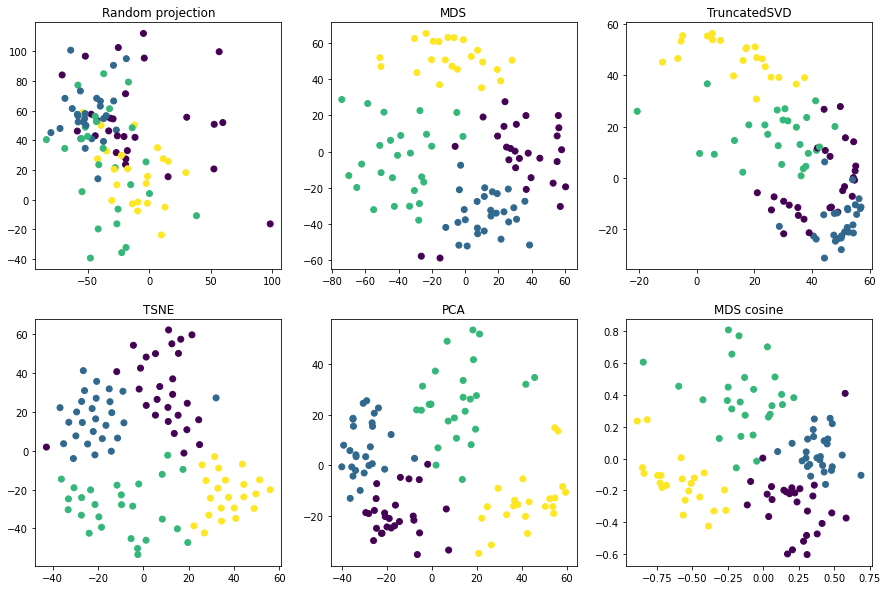

```python
model = KMeans(n_clusters=4, random_state=42)
predictions = model.fit_predict(data.T)

fig, axs = plt.subplots(2, 3, figsize=(15, 10))
vals = np.array(data).T

obs = [SparseRandomProjection(2, random_state=42),
       PCA(2, random_state=42),
       TruncatedSVD(2, random_state=42),
       TSNE(2, perplexity=23, learning_rate=200, random_state=42),
       MDS(2, random_state=42)]
titles = ['Random projection', 'PCA', 'TruncatedSVD', 'TSNE', 'MDS']
for i in range(len(obs)):
    points = obs[i].fit_transform(vals)
    ax = axs[i%2, i%3]
    ax.scatter([j[0] for j in points], [j[1] for j in points], c=predictions)
    ax.set_title(titles[i])
mds_model = MDS(n_components=2, dissimilarity='precomputed')
points = mds_model.fit_transform(pairwise_distances(vals, metric='cosine'))
ax = axs[-1, -1]
ax.scatter([j[0] for j in points], [j[1] for j in points], c=predictions)
ax.set_title('MDS cosine')
plt.show()
```

##### Нарисуем кластеры на карте

```python
# создадим таблицу в котором будет указано к какому кластеру относится каждый регион
regions = REGIONS.copy()
regions.set_index('region', inplace=True)
regions = regions.loc[map(int, COLUMNS_FROM_2_WEEK)]
regions['cluster'] = predictions
regions.head()
```

| region | west | east | south | north | cluster |
| --- | --- | --- | --- | --- | --- |
| 1075 | -74.022246 | -74.011135 | 40.697437 | 40.705825 | 0 |
| 1076 | -74.022246 | -74.011135 | 40.705825 | 40.714213 | 1 |
| 1077 | -74.022246 | -74.011135 | 40.714213 | 40.722601 | 1 |
| 1125 | -74.011135 | -74.000023 | 40.697437 | 40.705825 | 0 |
| 1126 | -74.011135 | -74.000023 | 40.705825 | 40.714213 | 0 |

[figure not shown]

```python
center_ny = [np.mean([40.49612, 40.91553]), np.mean([-74.25559, -73.70001])]
# готовим geojson для отрисовки регионов на карте
feature_list = []
for i in range(len(regions)):
  geometry = geojson.Polygon([[[regions.iloc[i][0], regions.iloc[i][2]],
                              [regions.iloc[i][0], regions.iloc[i][3]],
                              [regions.iloc[i][1], regions.iloc[i][3]],
                              [regions.iloc[i][1], regions.iloc[i][2]],
                              [regions.iloc[i][0], regions.iloc[i][2]]]])
  cluster = regions.iloc[i].cluster
  feature = geojson.Feature(id=str(i), geometry=geometry, properties={'cluster': cluster})
  feature_list.append(feature)

coord = geojson.FeatureCollection(feature_list)

# рисуем карту
m = folium.Map(location=center_ny, width=600, height=600, zoom_start=11)
folium.GeoJson(coord, style_function=my_style_function

                  ).add_to(m)
# вывожу заранее сохраненную карту, так как работаю в google colab
img = plt.imread('map.png')
plt.figure(figsize=(10,10))
plt.imshow(img)
plt.show()
```

##### Определим регионы, которые ближе всего к центрам кластеров

```python
distances = []
# посчитаем расстояние между векторами центров кластеров и количеством поездок в каждом регионе
for i in range(len(regions)):
  distances.append(distance.euclidean(model.cluster_centers_[int(regions.iloc[i].cluster)],
                                      data.T.iloc[i]))

regions['distance_to_center'] = distances
regions.head()
```

| region | west | east | south | north | cluster | distance_to_center |
| --- | --- | --- | --- | --- | --- | --- |
| 1075 | -74.022246 | -74.011135 | 40.697437 | 40.705825 | 0 | 30.607274 |
| 1076 | -74.022246 | -74.011135 | 40.705825 | 40.714213 | 1 | 24.967498 |
| 1077 | -74.022246 | -74.011135 | 40.714213 | 40.722601 | 1 | 25.989073 |
| 1125 | -74.011135 | -74.000023 | 40.697437 | 40.705825 | 0 | 27.450385 |
| 1126 | -74.011135 | -74.000023 | 40.705825 | 40.714213 | 0 | 24.333580 |

```python
# определим ближайшие регионы к центру кластеров (Номер региона, Номер кластера)
closest_regions = [(regions[regions['cluster'] == x].sort_values(by='distance_to_center').iloc[0].name, x) for x in range(4)]
closest_regions
```

```
[(1233, 0), (1333, 1), (1387, 2), (1326, 3)]
```

##### Нарисуем количество вызовов такси для регионов, которые ближе всего к центрам кластера

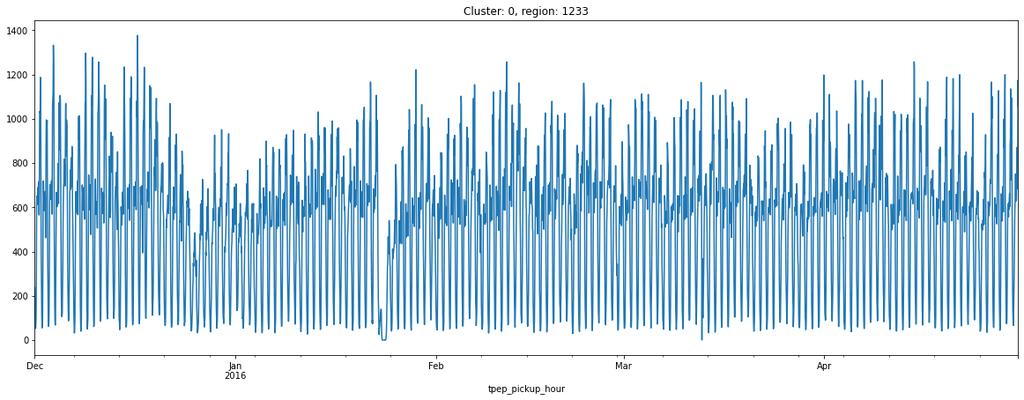

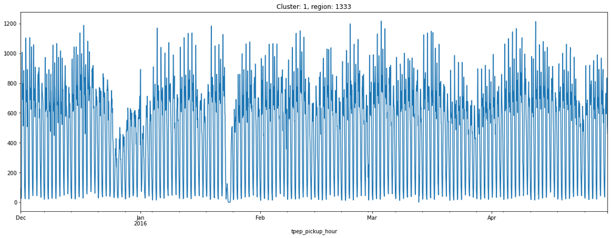

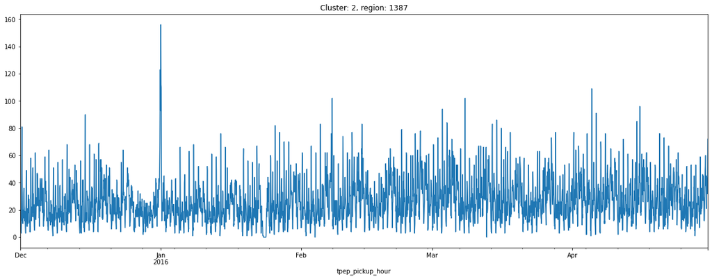

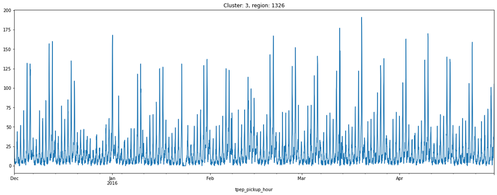

```python
data = load_data(AGG_FILES, date_after=datetime.datetime(2015, 12, 1), date_before=datetime.datetime(2016, 4, 30, 23))
for region in closest_regions:
  plt.figure(figsize=(20, 7))
  data[str(region[0])].plot(title=f'Cluster: {region[1]}, region: {region[0]}')
  plt.show()
```

Действительно, между данными регионами видно различие

### Добавляем признаки, строим линейную регрессию, подбираем параметры ARIMA

```python
K = 200
HOLIDAYS = USFederalHolidayCalendar().holidays(start=datetime.datetime(2015, 12, 1), end=datetime.datetime(2016, 6, 1))
params = []
```

##### Кластер 0

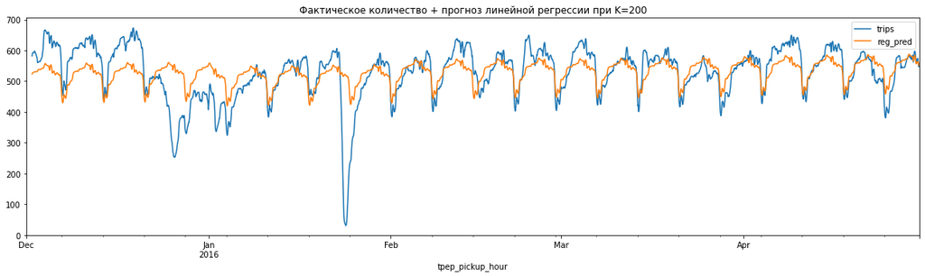

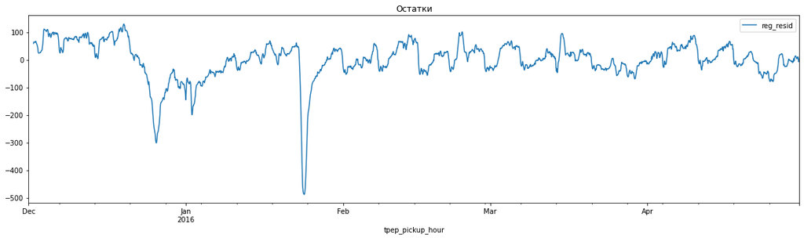

```
Критерий Дики-Фуллера: p=0.000002
```

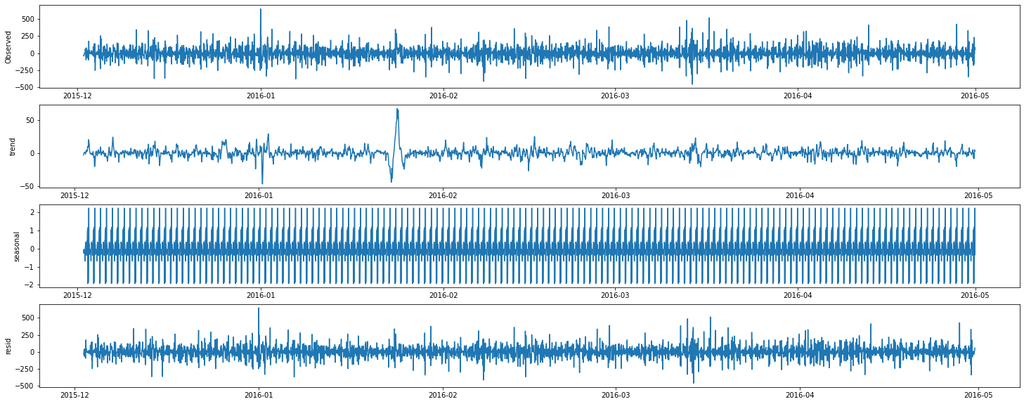

```
Строим полную и частичную автокорреляцию
```

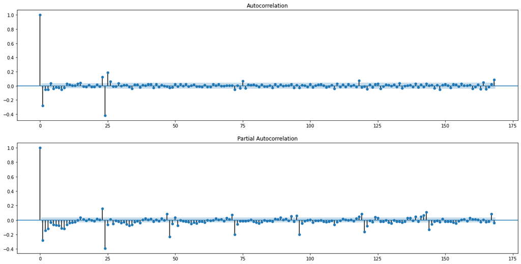

```python
# загружаем один регион, который ближе всего к центру кластера 0
data_cluster0 = load_data_cluster(cluster=0, date_after=datetime.datetime(2015, 12, 1), date_before=datetime.datetime(2016, 4, 30, 23))

# создадим линейную регрессию и нарисуем график фактического количества вызовов такси с прогнозом
plot_linear_reg(data_cluster0)

# сделаем дифференцирование сезонное дифференцирование на 24 часа + одно обычное
data_cluster0['reg_resid_diff'] = data_cluster0.reg_resid - data_cluster0.reg_resid.shift(24)
data_cluster0['reg_resid_diff'] = data_cluster0.reg_resid_diff - data_cluster0.reg_resid_diff.shift(1)

# нарисуем sm.tsa.seasonal_decompose, визуально проверим стационарность
plot_decompose(data_cluster0, 'reg_resid_diff')

# нарисуем графики полной и частичной автокорреляции
plot_acf_pacf(data_cluster0)
```

Начальное приближение возьмем поменьше, так как даже google colab умирает с большими значениями параметров из-за нехватки оперативной памяти

```python
# Начальное приближение
d=1
D=1
Qs = range(0, 2)
qs = range(0, 2)
Ps = range(0, 3)
ps = range(0, 3)

parameters = product(ps, qs, Ps, Qs)
parameters_list = list(parameters)
params.append(parameters_list)
len(parameters_list)
```

```
36
```

##### Кластер 1

Повторим по аналогии с кластером № 0

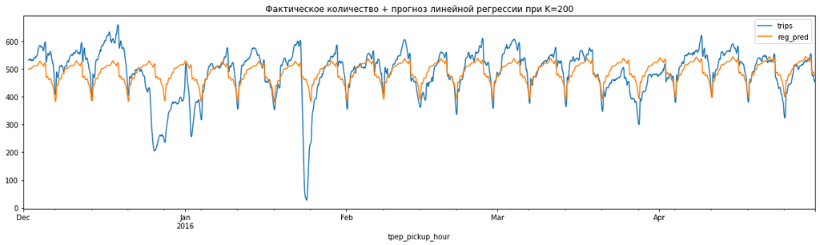

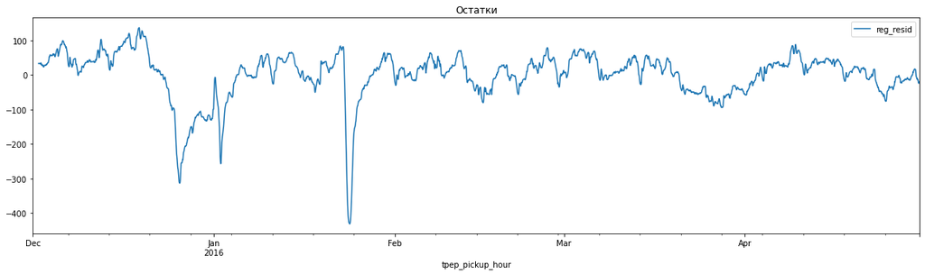

```
Критерий Дики-Фуллера: p=0.000002
```

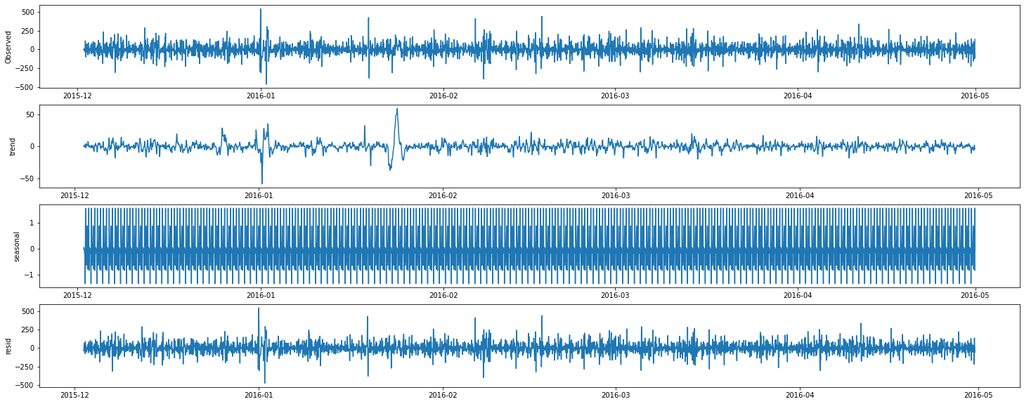

```
Строим полную и частичную автокорреляцию
```

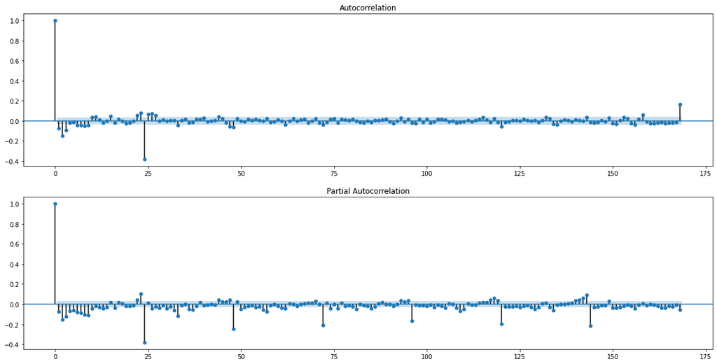

```python
data_cluster1 = load_data_cluster(1, date_after=datetime.datetime(2015, 12, 1), date_before=datetime.datetime(2016, 4, 30, 23))
plot_linear_reg(data_cluster1)
data_cluster1['reg_resid_diff'] = data_cluster1.reg_resid - data_cluster1.reg_resid.shift(24)
data_cluster1['reg_resid_diff'] = data_cluster1.reg_resid_diff - data_cluster1.reg_resid_diff.shift(1)
plot_decompose(data_cluster1, 'reg_resid_diff')
plot_acf_pacf(data_cluster1)
```

```python
# Начальное приближение
d=1
D=1
Qs = range(0, 2)
qs = range(1, 4)
Ps = range(1, 3)
ps = range(1, 3)

parameters = product(ps, qs, Ps, Qs)
parameters_list = list(parameters)
params.append(parameters_list)
len(parameters_list)
```

```
24
```

##### Кластер 2

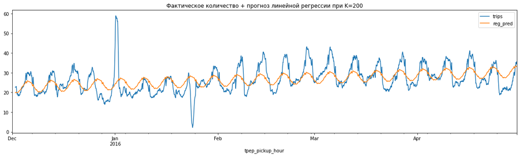

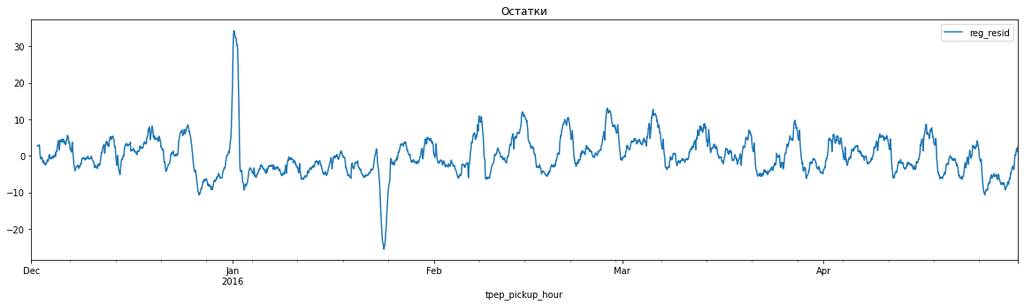

```
Критерий Дики-Фуллера: p=0.000000
```

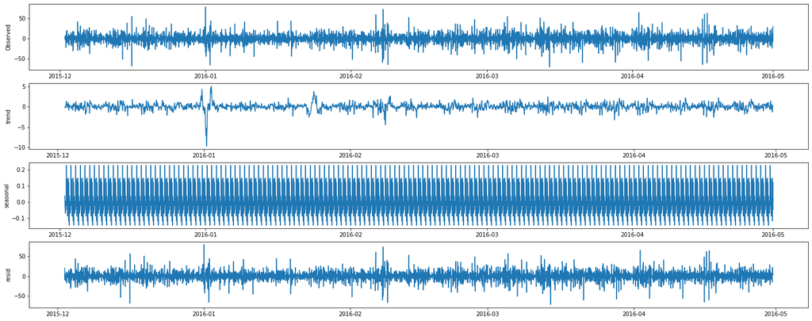

```
Строим полную и частичную автокорреляцию
```

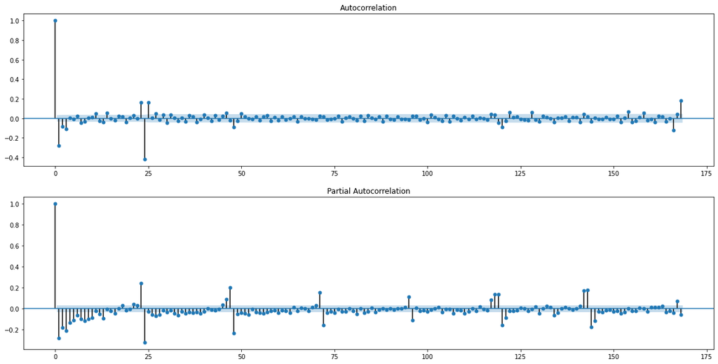

```python
data_cluster2 = load_data_cluster(2, date_after=datetime.datetime(2015, 12, 1), date_before=datetime.datetime(2016, 4, 30, 23))
plot_linear_reg(data_cluster2)
data_cluster2['reg_resid_diff'] = data_cluster2.reg_resid - data_cluster2.reg_resid.shift(24)
data_cluster2['reg_resid_diff'] = data_cluster2.reg_resid_diff - data_cluster2.reg_resid_diff.shift(1)
plot_decompose(data_cluster2, 'reg_resid_diff')
plot_acf_pacf(data_cluster2)
```

```python
# Начальное приближение
d=1
D=1
Qs = range(0, 2)
qs = range(1, 3)
Ps = range(1, 3)
ps = range(1, 3)

parameters = product(ps, qs, Ps, Qs)
parameters_list = list(parameters)
params.append(parameters_list)
len(parameters_list)
```

```
16
```

##### Кластер 3

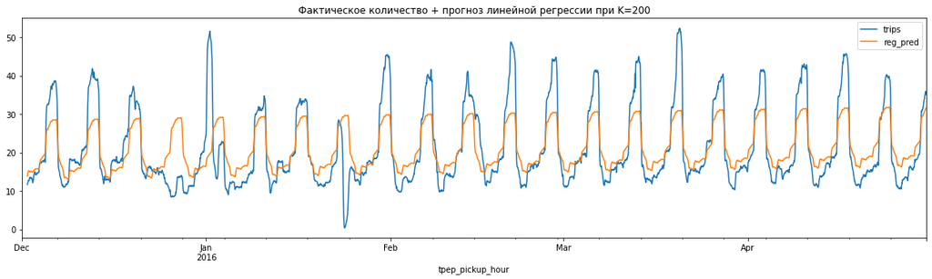

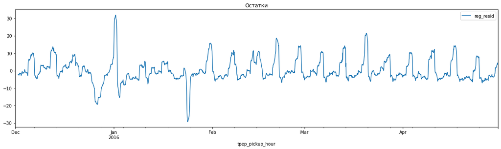

```
Критерий Дики-Фуллера: p=0.000000
```

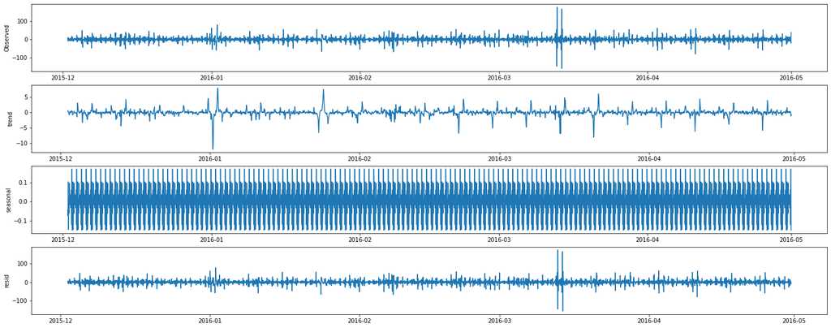

```
Строим полную и частичную автокорреляцию
```

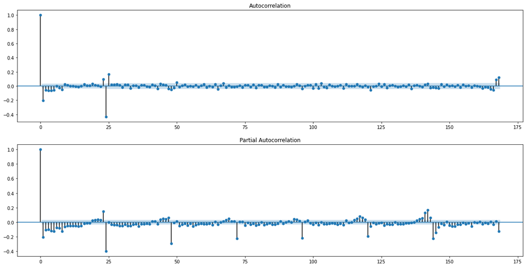

```python
data_cluster3 = load_data_cluster(3,date_after=datetime.datetime(2015, 12, 1), date_before=datetime.datetime(2016, 4, 30, 23))
plot_linear_reg(data_cluster3)
data_cluster3['reg_resid_diff'] = data_cluster3.reg_resid - data_cluster3.reg_resid.shift(24)
data_cluster3['reg_resid_diff'] = data_cluster3.reg_resid_diff - data_cluster3.reg_resid_diff.shift(1)
plot_decompose(data_cluster3, 'reg_resid_diff')
plot_acf_pacf(data_cluster3)
```

```python
# Начальное приближение
d=1
D=1
Qs = range(0, 2)
qs = range(0, 2)
Ps = range(1, 3)
ps = range(1, 3)

parameters = product(ps, qs, Ps, Qs)
parameters_list = list(parameters)
params.append(parameters_list)
len(parameters_list)
```

```
16
```

### Обучаем ARIMA на данных до мая 2016

##### Кластер 0

```python
%%time
model_0, results_0 = select_best_arima(data_cluster0, params[0], d=1, D=1)
print(model_0.summary())
dump(model_0, 'model_0.joblib')
results_0
```

```
                                 Statespace Model Results
==========================================================================================
Dep. Variable:                          reg_resid   No. Observations:                 3648
Model:             SARIMAX(2, 1, 1)x(1, 1, 1, 24)   Log Likelihood              -20311.493
Date:                            Sun, 20 Jun 2021   AIC                          40634.985
Time:                                    12:10:43   BIC                          40672.155
Sample:                                12-01-2015   HQIC                         40648.227
                                     - 04-30-2016
Covariance Type:                              opg
==============================================================================
                 coef    std err          z      P>|z|      [0.025      0.975]
------------------------------------------------------------------------------
ar.L1          0.7423      0.011     67.424      0.000       0.721       0.764
ar.L2          0.1043      0.012      8.716      0.000       0.081       0.128
ma.L1         -0.9989      0.002   -447.353      0.000      -1.003      -0.994
ar.S.L24       0.3031      0.012     24.460      0.000       0.279       0.327
ma.S.L24      -0.9990      0.049    -20.398      0.000      -1.095      -0.903
sigma2      4183.3364    202.309     20.678      0.000    3786.818    4579.855
===================================================================================
Ljung-Box (Q):                      286.54   Jarque-Bera (JB):              2334.28
Prob(Q):                              0.00   Prob(JB):                         0.00
Heteroskedasticity (H):               0.97   Skew:                             0.27
Prob(H) (two-sided):                  0.57   Kurtosis:                         6.89
===================================================================================

Warnings:
[1] Covariance matrix calculated using the outer product of gradients (complex-step).
```

```
[[(0, 0, 0, 0), 42723.18856968805],
 [(0, 0, 0, 1), 41147.49890319647],
 [(0, 0, 1, 0), 42014.85999759041],
 [(0, 0, 1, 1), 41076.71609037992],
 [(0, 0, 2, 0), 41785.97518221518],
 [(0, 0, 2, 1), 41093.353017303],
 [(0, 1, 0, 0), 42317.07745650133],
 [(0, 1, 0, 1), 40918.244585418164],
 [(0, 1, 1, 0), 41715.849510028784],
 [(0, 1, 1, 1), 40853.53735709862],
 [(0, 1, 2, 0), 41512.0856101137],
 [(0, 1, 2, 1), 41086.10375104836],
 [(1, 0, 0, 0), 42420.935152513804],
 [(1, 0, 0, 1), 40962.4879655878],
 [(1, 0, 1, 0), 41784.68182755693],
 [(1, 0, 1, 1), 40961.00508008826],
 [(1, 0, 2, 0), 41570.64132491709],
 [(1, 0, 2, 1), 41143.850557786915],
 [(1, 1, 0, 0), 42133.49604096293],
 [(1, 1, 0, 1), 40682.805711666544],
 [(1, 1, 1, 0), 41503.86689371386],
 [(1, 1, 1, 1), 40638.14673324952],
 [(1, 1, 2, 0), 41364.907065879794],
 [(1, 1, 2, 1), 40837.11311491522],
 [(2, 0, 0, 0), 42348.20637530036],
 [(2, 0, 0, 1), 41059.65368311042],
 [(2, 0, 1, 0), 41735.59837807588],
 [(2, 0, 1, 1), 40932.79544460185],
 [(2, 0, 2, 0), 41532.101915037376],
 [(2, 0, 2, 1), 41092.33864608289],
 [(2, 1, 0, 0), 42045.476872169136],
 [(2, 1, 0, 1), 40642.63910105309],
 [(2, 1, 1, 0), 41441.22780078769],
 [(2, 1, 1, 1), 40634.9851232848],
 [(2, 1, 2, 0), 41231.43547521118],
 [(2, 1, 2, 1), 40763.88976205778]]
```

##### Кластер 1

```python
%%time
model_0 = None
model_1, results_1 = select_best_arima(data_cluster1, params[1], d=1, D=1)
print(model_1.summary())
dump(model_1, 'model_1.joblib')
results_1
```

```
                                 Statespace Model Results
==========================================================================================
Dep. Variable:                          reg_resid   No. Observations:                 3648
Model:             SARIMAX(2, 1, 1)x(1, 1, 1, 24)   Log Likelihood              -19769.617
Date:                            Sun, 20 Jun 2021   AIC                          39551.234
Time:                                    12:43:29   BIC                          39588.405
Sample:                                12-01-2015   HQIC                         39564.477
                                     - 04-30-2016
Covariance Type:                              opg
==============================================================================
                 coef    std err          z      P>|z|      [0.025      0.975]
------------------------------------------------------------------------------
ar.L1          0.8793      0.011     80.839      0.000       0.858       0.901
ar.L2         -0.0966      0.012     -7.845      0.000      -0.121      -0.072
ma.L1         -0.9980      0.001   -736.618      0.000      -1.001      -0.995
ar.S.L24       0.3036      0.010     29.987      0.000       0.284       0.323
ma.S.L24      -0.9993      0.058    -17.236      0.000      -1.113      -0.886
sigma2      3113.3589    178.709     17.421      0.000    2763.096    3463.622
===================================================================================
Ljung-Box (Q):                      220.90   Jarque-Bera (JB):              4748.65
Prob(Q):                              0.00   Prob(JB):                         0.00
Heteroskedasticity (H):               0.74   Skew:                             0.09
Prob(H) (two-sided):                  0.00   Kurtosis:                         8.61
===================================================================================

Warnings:
[1] Covariance matrix calculated using the outer product of gradients (complex-step).
```

```
[[(1, 1, 1, 0), 40461.27610533341],
 [(1, 1, 1, 1), 39581.13409191671],
 [(1, 1, 2, 0), 40292.340998908345],
 [(1, 1, 2, 1), 39867.561650659874],
 [(1, 2, 1, 0), 40452.753648884696],
 [(1, 2, 1, 1), 39618.24707755481],
 [(1, 2, 2, 0), 40209.6882072834],
 [(1, 2, 2, 1), 39586.72302258622],
 [(1, 3, 1, 0), 40425.24908154026],
 [(1, 3, 1, 1), 39716.194936866625],
 [(1, 3, 2, 0), 40247.61562342406],
 [(1, 3, 2, 1), 39783.204062905286],
 [(2, 1, 1, 0), 40411.603660830384],
 [(2, 1, 1, 1), 39551.234204326436],
 [(2, 1, 2, 0), 40181.21353555612],
 [(2, 1, 2, 1), 39657.79454952486],
 [(2, 2, 1, 0), 40412.02752065947],
 [(2, 2, 1, 1), 39571.88883295833],
 [(2, 2, 2, 0), 40279.80692637849],
 [(2, 2, 2, 1), 39746.85222025345],
 [(2, 3, 1, 0), 40463.029225477716],
 [(2, 3, 1, 1), 39833.32290909918],
 [(2, 3, 2, 0), 40298.90921536907],
 [(2, 3, 2, 1), 39842.59775345928]]
```

##### Кластер 2

```python
%%time
model_1 = None
model_2, results_2 = select_best_arima(data_cluster2, params[2], d=1, D=1)
print(model_2.summary())
dump(model_2, 'model_2.joblib')
results_2
```

```
                                 Statespace Model Results
==========================================================================================
Dep. Variable:                          reg_resid   No. Observations:                 3648
Model:             SARIMAX(2, 1, 2)x(2, 1, 1, 24)   Log Likelihood              -13045.948
Date:                            Sun, 20 Jun 2021   AIC                          26107.896
Time:                                    13:01:24   BIC                          26157.456
Sample:                                12-01-2015   HQIC                         26125.552
                                     - 04-30-2016
Covariance Type:                              opg
==============================================================================
                 coef    std err          z      P>|z|      [0.025      0.975]
------------------------------------------------------------------------------
ar.L1         -0.3065      0.112     -2.728      0.006      -0.527      -0.086
ar.L2          0.5004      0.060      8.305      0.000       0.382       0.619
ma.L1         -0.1304      0.115     -1.136      0.256      -0.356       0.095
ma.L2         -0.8512      0.113     -7.500      0.000      -1.074      -0.629
ar.S.L24       0.1267      0.013     10.016      0.000       0.102       0.152
ar.S.L48      -0.0653      0.015     -4.407      0.000      -0.094      -0.036
ma.S.L24      -0.9726      0.005   -206.829      0.000      -0.982      -0.963
sigma2        77.3450      0.936     82.603      0.000      75.510      79.180
===================================================================================
Ljung-Box (Q):                      136.52   Jarque-Bera (JB):             10187.70
Prob(Q):                              0.00   Prob(JB):                         0.00
Heteroskedasticity (H):               1.11   Skew:                             1.18
Prob(H) (two-sided):                  0.08   Kurtosis:                        10.87
===================================================================================

Warnings:
[1] Covariance matrix calculated using the outer product of gradients (complex-step).
```

```
[[(1, 1, 1, 0), 27424.183493374883],
 [(1, 1, 1, 1), 26134.180537286233],
 [(1, 1, 2, 0), 27006.21304890927],
 [(1, 1, 2, 1), 26118.156571117444],
 [(1, 2, 1, 0), 27428.322179684474],
 [(1, 2, 1, 1), 26137.757076869842],
 [(1, 2, 2, 0), 27009.464906263842],
 [(1, 2, 2, 1), 26130.542024057606],
 [(2, 1, 1, 0), 27423.539058229813],
 [(2, 1, 1, 1), 26125.228186287808],
 [(2, 1, 2, 0), 27067.115700644972],
 [(2, 1, 2, 1), 26111.851874756954],
 [(2, 2, 1, 0), 27406.530064349936],
 [(2, 2, 1, 1), 26120.981864896203],
 [(2, 2, 2, 0), 27004.444925891257],
 [(2, 2, 2, 1), 26107.895620924737]]
```

##### Кластер 3

```python
%%time
model_2 = None
model_3, results_3 = select_best_arima(data_cluster3, params[3], d=1, D=1)
print(model_3.summary())
dump(model_3, 'model_3.joblib')
results_3
```

```
                                 Statespace Model Results
==========================================================================================
Dep. Variable:                          reg_resid   No. Observations:                 3648
Model:             SARIMAX(1, 1, 1)x(2, 1, 1, 24)   Log Likelihood              -13256.267
Date:                            Sun, 20 Jun 2021   AIC                          26524.534
Time:                                    13:17:18   BIC                          26561.704
Sample:                                12-01-2015   HQIC                         26537.776
                                     - 04-30-2016
Covariance Type:                              opg
==============================================================================
                 coef    std err          z      P>|z|      [0.025      0.975]
------------------------------------------------------------------------------
ar.L1          0.7000      0.007    100.919      0.000       0.686       0.714
ma.L1         -0.9875      0.003   -290.526      0.000      -0.994      -0.981
ar.S.L24       0.1032      0.010     10.474      0.000       0.084       0.123
ar.S.L48      -0.0505      0.013     -3.842      0.000      -0.076      -0.025
ma.S.L24      -0.9904      0.005   -192.189      0.000      -1.001      -0.980
sigma2        84.2558      0.629    133.971      0.000      83.023      85.488
===================================================================================
Ljung-Box (Q):                       74.76   Jarque-Bera (JB):            189490.59
Prob(Q):                              0.00   Prob(JB):                         0.00
Heteroskedasticity (H):               1.55   Skew:                             0.95
Prob(H) (two-sided):                  0.00   Kurtosis:                        38.38
===================================================================================

Warnings:
[1] Covariance matrix calculated using the outer product of gradients (complex-step).
```

```
[[(1, 0, 1, 0), 28328.333317186247],
 [(1, 0, 1, 1), 26973.206677832935],
 [(1, 0, 2, 0), 28012.564700722705],
 [(1, 0, 2, 1), 26962.227694771012],
 [(1, 1, 1, 0), 27866.32057606394],
 [(1, 1, 1, 1), 26528.52301336345],
 [(1, 1, 2, 0), 27554.620495058167],
 [(1, 1, 2, 1), 26524.53409996369],
 [(2, 0, 1, 0), 28288.138016804594],
 [(2, 0, 1, 1), 26939.929249349927],
 [(2, 0, 2, 0), 27978.13746727236],
 [(2, 0, 2, 1), 26930.92862958061],
 [(2, 1, 1, 0), 27891.266455742207],
 [(2, 1, 1, 1), 26538.307847230022],
 [(2, 1, 2, 0), 27571.83160187795],
 [(2, 1, 2, 1), 26530.68338499972]]
```

### Делаем динамический прогноз на 6 часов вперед для каждого часа мая 2016

##### Попробуем вначале на одном регионе в кластере №0

```python
%%time
END_APRIL = datetime.datetime(2016, 4, 30, 23)
CUMULATIVE_ERROR = 0
K = 200
# загружаем данные до апреля 2016
data = load_data(AGG_FILES,
                 date_after=datetime.datetime(2015, 12, 1, 0),
                 date_before=datetime.datetime(2016, 5, 31, 23))
data = pd.DataFrame(data['1233']) # выбираем 1233 регион
data.columns = ['trips']
features_columns = add_features(data, K, HOLIDAYS)

# обучаем линейную регрессионную модель на данных до мая 2016
train_data = np.array(data[features_columns].loc[:END_APRIL])
train_y = np.array(data['trips'].loc[:END_APRIL])
model_reg = ElasticNet(random_state=42)
model_reg.fit(train_data, train_y)

# получаем прогноз линейной модели и добавляем её в основной dataframe
preds = model_reg.predict(data[features_columns])
data['reg_pred'] = preds
data['reg_resid'] = data['trips'] - preds

# обучаем SARIMAX на данных до мая 2016 с параметрами своего кластера

model_res = sm.tsa.statespace.SARIMAX(data.reg_resid.loc[:END_APRIL],
                                      order=(2, 1, 1),
                                      seasonal_order=(1, 1, 1, 24)).fit(disp=False, maxiter=50)

#model_res = load('model_0.joblib')

# создаем вторую модель с .filter предыдущей модели
model_fitted = sm.tsa.statespace.SARIMAX(data.reg_resid,
                                         order=(2, 1, 1),
                                         seasonal_order=(1, 1, 1, 24)
                                         ).filter(model_res.params)


# получаем начальное время среза для подсчета ошибки
start = END_APRIL + datetime.timedelta(hours=1)
predictions_reg_arima = pd.DataFrame(index=pd.date_range(start=datetime.datetime(2016, 5, 1),
                                                         end=datetime.datetime(2016, 5, 31, 23),
                                                         freq='H'),
                                     columns=['pred'])
for i in range(739): # цикл на 739 итераций
  # получаем конечное время среза для подсчета ошибки
  end = start + datetime.timedelta(hours=5)

  # суммируем предсказания линейной регрессии и модели ARIMA на 6 часов вперед
  predictions = data.reg_pred.loc[start:end] + model_fitted.predict(start=start, end=end, dynamic=True)
  predictions_reg_arima['pred'].loc[start:end] = predictions

  # получаем истинные значения поездок
  trips = data.trips.loc[start:end]

  # считаем ошибку
  CUMULATIVE_ERROR += abs(trips - predictions).sum()

  # добавляем один час для перехода на следующую итерацию
  start = start + datetime.timedelta(hours=1)
```

```
53.831740546342125
```

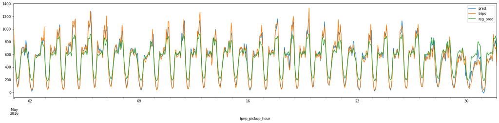

```python
print(CUMULATIVE_ERROR / (6*739))
plt.figure(figsize=(25,5))
predictions_reg_arima.pred.plot()
data.trips.loc[END_APRIL:].plot()
data.reg_pred.loc[END_APRIL:].plot()
plt.legend()
plt.show()
```

Визуально, результат хороший.

##### Посчитаем ошибку для всех регионов

```python
%%time
END_APRIL = datetime.datetime(2016, 4, 30, 23)
CUMULATIVE_ERROR = 0
HOLIDAYS = USFederalHolidayCalendar().holidays(start=datetime.datetime(2015, 12, 1), end=datetime.datetime(2016, 6, 1))
K = 200
params = {0: [2, 1, 1, 1, 1, 1, 24],
          1: [2, 1, 1, 1, 1, 1, 24],
          2: [2, 1, 2, 2, 1, 1, 24],
          3: [1, 1, 1, 2, 1, 1, 24]}


for i in range(len(regions)): # цикл на 102 итерации (количество регионов с задания второй недели)
  # задаем переменные
  region_num = str(regions.iloc[i].name)
  cluster_num = int(regions.iloc[i].cluster)
  param = params.get(cluster_num)
  cumulative_error = 0

  # загружаем данные и создаем признаки
  data = load_data(AGG_FILES,
                  date_after=datetime.datetime(2015, 12, 1, 0),
                  date_before=datetime.datetime(2016, 5, 31, 23))
  data = pd.DataFrame(data[region_num])
  data.columns = ['trips']
  features_columns = add_features(data, K, HOLIDAYS)

  # обучаем линейную регрессионную модель на данных до мая 2016
  train_data = np.array(data[features_columns].loc[:END_APRIL])
  train_y = np.array(data['trips'].loc[:END_APRIL])
  model_reg = ElasticNet(random_state=42)
  model_reg.fit(train_data, train_y)

  # получаем прогноз линейной модели и добавляем её в основной dataframe
  preds = model_reg.predict(data[features_columns])
  data['reg_pred'] = preds
  data['reg_resid'] = data['trips'] - preds

  # обучаем SARIMAX на данных до мая 2016 с параметрами своего кластера
  model_res = sm.tsa.statespace.SARIMAX(data.reg_resid.loc[:END_APRIL],
                                        order=(param[0], param[1], param[2]),
                                        seasonal_order=(param[3], param[4], param[5], param[6])
                                        ).fit(disp=False, maxiter=15)

  # создаем вторую модель с .filter предыдущей модели
  model_fitted = sm.tsa.statespace.SARIMAX(data.reg_resid,
                                          order=(param[0], param[1], param[2]),
                                          seasonal_order=(param[3], param[4], param[5], param[6])
                                          ).filter(model_res.params)


  # получаем начальное время среза для подсчета ошибки
  start = END_APRIL + datetime.timedelta(hours=1)

  for _ in range(739): # цикл на 739 итераций с 30.04.2016 23:00 до 31.05.2021 17:00
    # получаем конечное время среза для подсчета ошибки
    end = start + datetime.timedelta(hours=5)

    # суммируем предсказания линейной регрессии и модели ARIMA на 6 часов вперед
    predictions = data.reg_pred.loc[start:end] + model_fitted.predict(start=start, end=end, dynamic=True)

    # получаем истинные значения поездок
    trips = data.trips.loc[start:end]

    # считаем ошибку
    cumulative_error += abs(trips - predictions).sum()

    # добавляем один час
    start = start + datetime.timedelta(hours=1)
  print(f'i: {i}, Кластер: {cluster_num}, Регион: {region_num}, Ошибка: {cumulative_error / (6 * 739)}')
  CUMULATIVE_ERROR += cumulative_error
```

```
i: 0, Кластер: 0, Регион: 1075, Ошибка: 12.25824245093954
i: 1, Кластер: 1, Регион: 1076, Ошибка: 17.759682657591938
i: 2, Кластер: 1, Регион: 1077, Ошибка: 13.885339535560812
i: 3, Кластер: 0, Регион: 1125, Ошибка: 11.670040898084208
i: 4, Кластер: 0, Регион: 1126, Ошибка: 28.12397243556928
i: 5, Кластер: 0, Регион: 1127, Ошибка: 39.250117497163856
i: 6, Кластер: 0, Регион: 1128, Ошибка: 37.37384763160381
i: 7, Кластер: 3, Регион: 1129, Ошибка: 42.624374075036876
i: 8, Кластер: 3, Регион: 1130, Ошибка: 58.31078556883866
i: 9, Кластер: 0, Регион: 1131, Ошибка: 26.346654670866812
i: 10, Кластер: 1, Регион: 1132, Ошибка: 17.348797264858558
i: 11, Кластер: 2, Регион: 1172, Ошибка: 3.363273969313835
i: 12, Кластер: 2, Регион: 1173, Ошибка: 7.913796448063451
i: 13, Кластер: 2, Регион: 1174, Ошибка: 7.411254849504471
i: 14, Кластер: 2, Регион: 1175, Ошибка: 4.8814561965747885
i: 15, Кластер: 3, Регион: 1176, Ошибка: 5.431477254980412
i: 16, Кластер: 3, Регион: 1177, Ошибка: 54.00462409101008
i: 17, Кластер: 3, Регион: 1178, Ошибка: 54.29353813014572
i: 18, Кластер: 0, Регион: 1179, Ошибка: 48.359544794994285
i: 19, Кластер: 0, Регион: 1180, Ошибка: 57.37433274271227
i: 20, Кластер: 1, Регион: 1181, Ошибка: 88.61533807717981
i: 21, Кластер: 2, Регион: 1182, Ошибка: 48.709012164447
i: 22, Кластер: 1, Регион: 1183, Ошибка: 20.75743212132727
i: 23, Кластер: 1, Регион: 1184, Ошибка: 5.149882471627517
i: 24, Кластер: 3, Регион: 1221, Ошибка: 2.8278395829146503
i: 25, Кластер: 3, Регион: 1222, Ошибка: 4.298475931179112
i: 26, Кластер: 3, Регион: 1223, Ошибка: 6.265040821052108
i: 27, Кластер: 2, Регион: 1224, Ошибка: 6.7319969933150805
i: 28, Кластер: 2, Регион: 1225, Ошибка: 2.745360561449628
i: 29, Кластер: 3, Регион: 1227, Ошибка: 28.5064180702224
i: 30, Кластер: 3, Регион: 1228, Ошибка: 54.202309254856345
i: 31, Кластер: 0, Регион: 1229, Ошибка: 50.1672640618709
i: 32, Кластер: 0, Регион: 1230, Ошибка: 81.07994435723437
i: 33, Кластер: 0, Регион: 1231, Ошибка: 68.92701423246018
i: 34, Кластер: 0, Регион: 1232, Ошибка: 71.59143971410894
i: 35, Кластер: 0, Регион: 1233, Ошибка: 56.640522370308815
i: 36, Кластер: 1, Регион: 1234, Ошибка: 38.17135314939807
i: 37, Кластер: 1, Регион: 1235, Ошибка: 18.906757638019656
i: 38, Кластер: 3, Регион: 1272, Ошибка: 3.4391889227258274
i: 39, Кластер: 3, Регион: 1273, Ошибка: 5.947181970358669
```

[output cut: 47 more lines]

```
i: 87, Кластер: 2, Регион: 1483, Ошибка: 3.499769038112494
i: 88, Кластер: 2, Регион: 1530, Ошибка: 4.296132522196932
i: 89, Кластер: 3, Регион: 1532, Ошибка: 3.009997110738602
i: 90, Кластер: 3, Регион: 1533, Ошибка: 3.790361798710889
i: 91, Кластер: 2, Регион: 1580, Ошибка: 2.456300629186841
i: 92, Кластер: 2, Регион: 1630, Ошибка: 2.383908476365192
i: 93, Кластер: 0, Регион: 1684, Ошибка: 6.728979898906838
i: 94, Кластер: 0, Регион: 1733, Ошибка: 2.3162641050724684
i: 95, Кластер: 0, Регион: 1734, Ошибка: 31.265811313845884
i: 96, Кластер: 0, Регион: 1783, Ошибка: 41.03741387329197
i: 97, Кластер: 0, Регион: 2068, Ошибка: 18.344178087004426
i: 98, Кластер: 0, Регион: 2069, Ошибка: 4.455572942578436
i: 99, Кластер: 0, Регион: 2118, Ошибка: 23.53965509656454
i: 100, Кластер: 0, Регион: 2119, Ошибка: 12.068091992098925
i: 101, Кластер: 0, Регион: 2168, Ошибка: 16.32973692670171
```

##### Создаем файл с результатом для kaggle

Аналогичный цикл из предыдущего шага с добавлением в обучающую выборку данных мая 2016

```python
%%time
END_APRIL = datetime.datetime(2016, 4, 30, 23)
END_MAY = datetime.datetime(2016, 5, 31, 23)
CUMULATIVE_ERROR = 0
HOLIDAYS = USFederalHolidayCalendar().holidays(start=datetime.datetime(2015, 12, 1), end=datetime.datetime(2016, 7, 1))
K = 200
PARAMS = {0: [2, 1, 1, 1, 1, 1, 24],
          1: [2, 1, 1, 1, 1, 1, 24],
          2: [2, 1, 2, 2, 1, 1, 24],
          3: [1, 1, 1, 2, 1, 1, 24]}

"""
создаем новый файл для kaggle и добавляем в него заголовок
with open('kaggle_answer.csv', 'w') as file:
  csv.writer(file).writerow(['id', 'y'])
"""

for i in range(len(regions)):
  # задаем переменные
  region_num = str(regions.iloc[i].name)
  cluster_num = int(regions.iloc[i].cluster)
  param = PARAMS.get(cluster_num)
  cumulative_error = 0

  # загружаем данные и создаем признаки
  data = load_data(AGG_FILES,
                  date_after=datetime.datetime(2015, 12, 1, 0),
                  date_before=datetime.datetime(2016, 6, 30, 23))
  data = pd.DataFrame(data[region_num])
  data.columns = ['trips']
  features_columns = add_features(data, K, HOLIDAYS)

  # обучаем линейную регрессионную модель на данных до июня 2016
  train_data = np.array(data[features_columns].loc[:END_MAY])
  train_y = np.array(data['trips'].loc[:END_MAY])
  model_reg = ElasticNet(random_state=42)
  model_reg.fit(train_data, train_y)

  # получаем прогноз линейной модели и добавляем её в основной dataframe
  preds = model_reg.predict(data[features_columns])
  data['reg_pred'] = preds
  data['reg_resid'] = data['trips'] - preds

  # обучаем SARIMAX на данных до июня 2016 с параметрами своего кластера

  model_res = sm.tsa.statespace.SARIMAX(data.reg_resid.loc[:END_MAY],
                                        order=(param[0], param[1], param[2]),
                                        seasonal_order=(param[3], param[4], param[5], param[6])
                                        ).fit(disp=False, maxiter=15)
  # создаем вторую модель с .filter предыдущей модели
  model_fitted = sm.tsa.statespace.SARIMAX(data.reg_resid,
                                          order=(param[0], param[1], param[2]),
                                          seasonal_order=(param[3], param[4], param[5], param[6])
                                          ).filter(model_res.params)

  # получаем начальное время среза для подсчета ошибки
  start = END_MAY + datetime.timedelta(hours=1)
  kaggle_answer = []
  for _ in range(715): # цикл на 715 итераций с 31.05.2016 23:00 до 30.06.2021 17:00
    # получаем конечное время среза для подсчета ошибки
    end = start + datetime.timedelta(hours=5)

    # суммируем предсказания линейной регрессии и модели ARIMA на 6 часов вперед
    predictions = data.reg_pred.loc[start:end] + model_fitted.predict(start=start, end=end, dynamic=True)

    # получаем истинные значения поездок
    trips = data.trips.loc[start:end]

    # считаем ошибку
    cumulative_error += abs(trips - predictions).sum()

    # добавляем ответы в список для загрузки в kaggle в требуемом формате
    kagle_id = start - datetime.timedelta(hours=1)
    for predict in zip(predictions, range(1,7)):
      kaggle_answer.append([region_num+'_'+str(kagle_id.strftime('%Y-%m-%d'))+'_'+str(kagle_id.hour)+'_'+str(predict[1]), str(int(round(predict[0], 0)))])

    # добавляем один час для следующего цикла
    start = start + datetime.timedelta(hours=1)

  # добавляем ответы в файл для загрузки в kaggle
  pd.DataFrame(kaggle_answer, columns=['id', 'y']).to_csv('kaggle_answer.csv', mode='a', index=False, header=False)
```

Получилось 18.47042

Насколько я вижу, сделать сабмишн уже не получится, так как соревнование закрыто. Скриншот с результатом из kaggle ниже

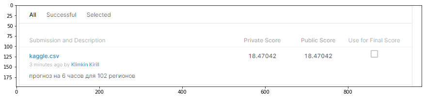

```python
img = plt.imread('kaggle.png')
plt.figure(figsize=(15,7))
plt.imshow(img)
plt.show()
```